# Course Project - Practicle Machine Learning

Swapnil Jadhav (saj1919@hotmail.com)

Sunday 26 April 2015

Import Needed libraries

```r
library(ggplot2)
library(caret)
library(randomForest)
library(gbm)
library(survival)
library(splines)
library(parallel)
library(plyr)
library(RColorBrewer)
library(rattle)
library(rpart)
library(rpart.plot)
```

Set working directory

```r
setwd('/home/saj1919/MyData/R Study/Practicle Machine Learning Course/project')
```

Check if files are in place

```r
dir()
```

```
##  [1] "Course_Project_-_Practicle_Machine_Learning.pdf"
##  [2] "pml-testing.csv"
##  [3] "pml-testing.csv~"
##  [4] "pml-training.csv"
##  [5] "problem_id_10.txt"
##  [6] "problem_id_11.txt"
##  [7] "problem_id_12.txt"
##  [8] "problem_id_13.txt"
##  [9] "problem_id_14.txt"
## [10] "problem_id_15.txt"
## [11] "problem_id_16.txt"
## [12] "problem_id_17.txt"
## [13] "problem_id_18.txt"
## [14] "problem_id_19.txt"
## [15] "problem_id_1.txt"
## [16] "problem_id_20.txt"
## [17] "problem_id_2.txt"
## [18] "problem_id_3.txt"
## [19] "problem_id_4.txt"
## [20] "problem_id_5.txt"
## [21] "problem_id_6.txt"
## [22] "problem_id_7.txt"
## [23] "problem_id_8.txt"
## [24] "problem_id_9.txt"
## [25] "project.html"
## [26] "project.R"
## [27] "project.Rmd"
```

Load train-test data

```r
training <- read.csv("pml-training.csv", row.names = 1)
testing <- read.csv("pml-testing.csv", row.names = 1)
```

In later steps, I got many errors during Random-forest run saying test and train data predictors do not match. So whatever transformation I am doing on train should also happen. So merging them.

Removing last column of test data.

```r
drops <- c("problem_id")
testing <- testing[,!(names(testing) %in% drops)]
```

Adding dummy last column named ‘classe’ with default value ‘A’.

```r
testing$classe <- "A"
```

Merging test and train data

```r
training <- rbind(training, testing)
```

Remove near zero covariates. Do not know if I am doing correct thing here. Found this online for removing DIV/0 and very small values

```r
nsv <- nearZeroVar(training, saveMetrics = T)
training <- training[, !nsv$nzv]
```

Data have many rows with less information. So keeping only data which have 1/4rth or more columns filled

```r
nav <- sapply(colnames(training), function(x) if(sum(is.na(training[, x])) > 0.75*nrow(training)){return(T)}else{return(F)})
training <- training[, !nav]
```

Now splitting test and train data to get orginal datasets

```r
testing <- training[19623:19642,]
training <- training[1:19622,]
```

Dividing data in 2/3rd training and 1/3rd testing

```r
inTrain <- createDataPartition(y=training$classe, p=0.67, list=FALSE)
myTraining <- training[inTrain, ]
myTesting <- training[-inTrain, ]
```

Week 3 videos lectures mostly talked about tree models. So here exploring with tree classifiers.

First using rpart

```r
set.seed(1919)
fit <- rpart(classe ~ ., data=myTraining, method="class")
```

Plot the decision tree

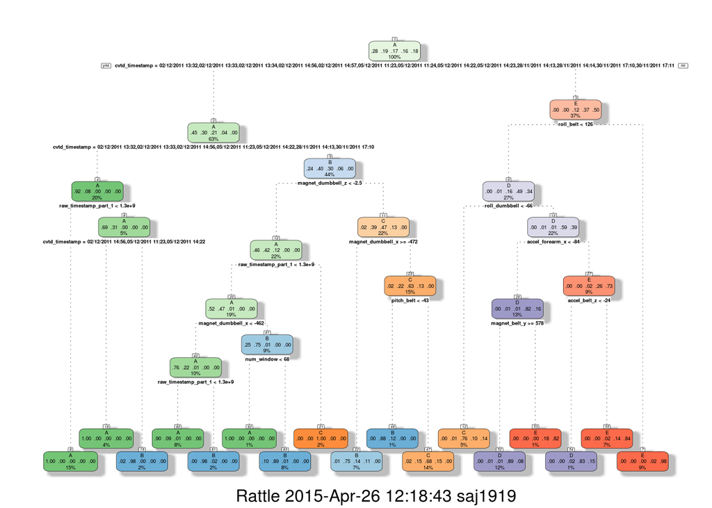

Display the fit.

```r
printcp(fit)
```

```
##
## Classification tree:
## rpart(formula = classe ~ ., data = myTraining, method = "class")
##
## Variables actually used in tree construction:
##  [1] accel_belt_z         accel_forearm_x      cvtd_timestamp
##  [4] magnet_belt_y        magnet_dumbbell_x    magnet_dumbbell_z
##  [7] num_window           pitch_belt           raw_timestamp_part_1
## [10] roll_belt            roll_dumbbell
##
## Root node error: 9409/13148 = 0.71562
##
## n= 13148
##
##          CP nsplit rel error  xerror      xstd
## 1  0.256882      0   1.00000 1.00000 0.0054976
## 2  0.102455      1   0.74312 0.74312 0.0060810
## 3  0.060368      2   0.64066 0.64066 0.0060723
## 4  0.053619      3   0.58030 0.58030 0.0060052
## 5  0.048996      5   0.47306 0.47348 0.0057681
## 6  0.021150      9   0.27708 0.28101 0.0048847
## 7  0.020619     10   0.25593 0.25699 0.0047212
## 8  0.014029     11   0.23531 0.23903 0.0045890
## 9  0.013285     12   0.22128 0.22617 0.0044885
## 10 0.012329     13   0.20799 0.21363 0.0043856
## 11 0.011000     14   0.19566 0.20300 0.0042943
## 12 0.010000     16   0.17366 0.17845 0.0040674
```

Plot cross-validation over fit

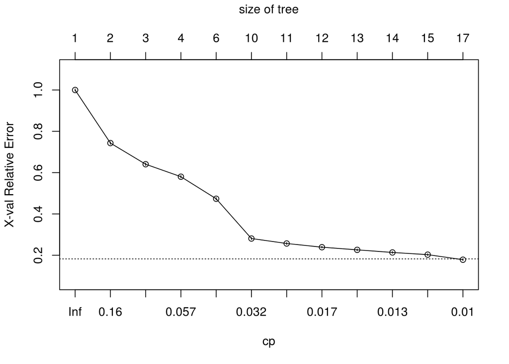

Predict and check accuracy

```r
predictions <- predict(fit, myTesting, type = "class")
confusionMatrix(predictions, myTesting$classe)
```

```
## Confusion Matrix and Statistics
##
##           Reference
## Prediction    A    B    C    D    E
##          A 1769   47    6    3    0
##          B   58 1059   80   58    0
##          C   14  141 1026  161   43
##          D    0    6   13  734   79
##          E    0    0    4  105 1068
##
## Overall Statistics
##
##                Accuracy : 0.8736
##                  95% CI : (0.8653, 0.8816)
##     No Information Rate : 0.2844
##     P-Value [Acc > NIR] : < 2.2e-16
##
##                   Kappa : 0.8402
##  Mcnemar's Test P-Value : NA
##
## Statistics by Class:
##
##                      Class: A Class: B Class: C Class: D Class: E
## Sensitivity            0.9609   0.8452   0.9088   0.6918   0.8975
## Specificity            0.9879   0.9625   0.9328   0.9819   0.9794
## Pos Pred Value         0.9693   0.8438   0.7408   0.8822   0.9074
## Neg Pred Value         0.9845   0.9628   0.9798   0.9420   0.9770
## Prevalence             0.2844   0.1935   0.1744   0.1639   0.1838
## Detection Rate         0.2732   0.1636   0.1585   0.1134   0.1650
## Detection Prevalence   0.2819   0.1939   0.2139   0.1285   0.1818
## Balanced Accuracy      0.9744   0.9038   0.9208   0.8368   0.9384
```

Didn’t cross 90% accuracy. Now try with Random-Forest

```r
set.seed(1919)
fit <- randomForest(classe ~. , data=myTraining)
```

Plot error with cross validation.

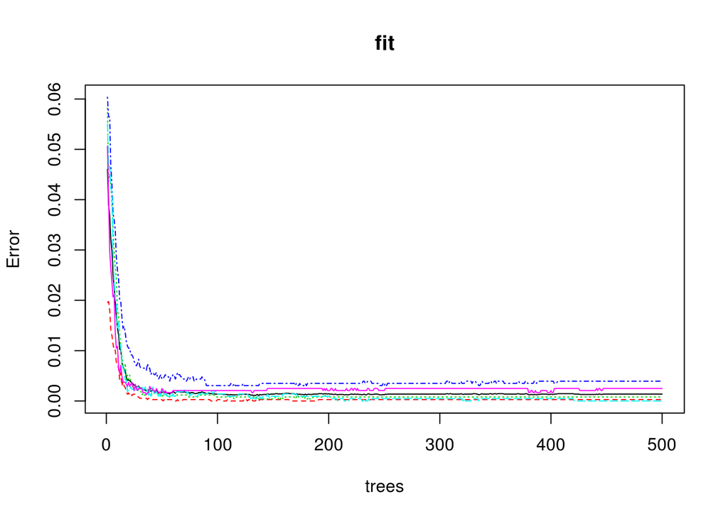

Predict and check accuracy

```r
predictions <- predict(fit, myTesting, type = "class")
confusionMatrix(predictions, myTesting$classe)
```

```
## Confusion Matrix and Statistics
##
##           Reference
## Prediction    A    B    C    D    E
##          A 1841    0    0    0    0
##          B    0 1253    2    0    0
##          C    0    0 1127    1    0
##          D    0    0    0 1059    0
##          E    0    0    0    1 1190
##
## Overall Statistics
##
##                Accuracy : 0.9994
##                  95% CI : (0.9984, 0.9998)
##     No Information Rate : 0.2844
##     P-Value [Acc > NIR] : < 2.2e-16
##
##                   Kappa : 0.9992
##  Mcnemar's Test P-Value : NA
##
## Statistics by Class:
##
##                      Class: A Class: B Class: C Class: D Class: E
## Sensitivity            1.0000   1.0000   0.9982   0.9981   1.0000
## Specificity            1.0000   0.9996   0.9998   1.0000   0.9998
## Pos Pred Value         1.0000   0.9984   0.9991   1.0000   0.9992
## Neg Pred Value         1.0000   1.0000   0.9996   0.9996   1.0000
## Prevalence             0.2844   0.1935   0.1744   0.1639   0.1838
## Detection Rate         0.2844   0.1935   0.1741   0.1636   0.1838
## Detection Prevalence   0.2844   0.1939   0.1742   0.1636   0.1840
## Balanced Accuracy      1.0000   0.9998   0.9990   0.9991   0.9999
```

Nice got > 99.9% accuracy !!!

Create model over all training data.

```r
set.seed(1919)
fit <- randomForest(classe ~. , data=training)
predictions <- predict(fit, testing, type = "class")
```

Generate Files for assignment generation

```r
pml_write_files = function(x){
  n = length(x)
  for(i in 1:n){
    filename = paste0("problem_id_",i,".txt")
    write.table(x[i],file=filename,quote=FALSE,row.names=FALSE,col.names=FALSE)
  }
}
pml_write_files(predictions)
```